# traminer demo

Todd Nobles

2025-05-06

## Data Cleaning

```r
library(TraMineR)
library(tidyverse)
library(bit64)
```

```r
monthly <- readRDS("/Volumes/ExtremeSSD/SIPP Data Files/rds/sipp_monthly_combined.rds")
joblevel_wide <- readRDS("/Volumes/ExtremeSSD/SIPP Data Files/rds/sipp_joblevel_combined_wide.rds")
```

```r
monthly <- monthly %>% mutate(
  ssuid = as.character.integer64(ssuid),
  ssuid_spanel_pnum = paste0(
        ssuid,
        as.character(spanel),
        as.character(pnum)
      ))


joblevel_wide <- joblevel_wide %>% mutate(
  ssuid = as.character.integer64(ssuid),
  ssuid_spanel_pnum = paste0(
        ssuid,
        as.character(spanel),
        as.character(pnum)
      )
)
```

Next we combine the monthly level dataframe with the wide joblevel file.

```r
full_data_base <- tidylog::left_join(monthly, joblevel_wide,
                                     by = c("ssuid_spanel_pnum", "spanel", "swave", "monthcode"))
```

```
## left_join: added 132 columns (ssuid.x, pnum.x, tage.x, ssuid.y, pnum.y, …)
##            > rows only in monthly                0
##            > rows only in joblevel_wide (        0)
##            > matched rows                6,210,463
##            >                            ===========
##            > rows total                  6,210,463
```

Then we filter to the working age population based on age at entry into dataset.

```r
full_data <- full_data_base %>%
  group_by(ssuid_spanel_pnum) %>%
  mutate(age_entry = min(tage.x),
         age_exit = max(tage.x)) %>%
  filter(age_entry >= 18 & age_entry <= 64) %>% ungroup()
```

They changed the coding of the unemployment flag (enjflag) between panels, so correcting for that here.

```r
# Unemployment flag is 0 = not unemployed and 1 = unemployed for 2014 panel. Then switches to 2 = not unemployed and 1 = unemployed for 2018 onwards. So recoding accordingly here
full_data <- full_data %>%
  mutate(enjflag_std = ifelse(spanel == 2014 & enjflag == 1, 1,
                              ifelse(spanel >2014 & enjflag == 1, 1,
                                     ifelse(enjflag == 0 | enjflag == 2, 0, NA))))
```

```r
rm(joblevel_wide, monthly)
full_data <- full_data %>%
  tidylog::select(-ends_with(".y"), -starts_with("ajb")) %>%
  rename_with(
    ~ gsub("^(tbsj\\d+)(val)$", "\\1_\\2", .), # adding in underscore to match the name formatting of tjb and ejb variables for easier reshaping
    starts_with("tbsj")
  )
```

```
## select: dropped 10 variables (ssuid.y, pnum.y, tage.y, ajb1_jobid, ajb2_jobid,
## …)
```

Most basic analysis is monthly level using the enjflag for unemployment during that month and then the ejb_jborse variable for the type of work in that month.

## Basic Monthly analysis

This presents the most basic one-job version just to get a feel for the methods. Future versions will account for people holding multiple jobs at once by modeling the sequence as follows:

Sequence: [1] 000-000-000-0W0-0W0-0W0-0W0-0W0-0W0-0W0-0W0-0W0-0WU-0WU-0WU-0WU [2] 000-000-000-0W0-0W0-0W0-0W0-0W0-0W0-0W0-0W0-0W0-0W0-0W0-0W0-0W0

For each state in the sequence, the first character stands for the number of children (0=no children, 1=1 children, etc…), the second character for the work status (0=not working, W=working) and the third character for the union status (0=not in union, U=in union). The alphabet contains 16 distinct states (see Table 1, page 376 in Aassve et al., 2007).

So ours will be something like the following where the first entry is their job with highest hours, second entry will be their job with second highest hours, etc.

[1] 123 - 123 - 123- 123

```r
sipp_seq <- full_data %>%
  select(ssuid_spanel_pnum, swave, monthcode, enjflag_std, contains("jborse")) %>%
  arrange(ssuid_spanel_pnum, swave, monthcode) %>%
  mutate(seq_month = case_when(
    swave == 1 ~ monthcode,
    swave == 2 ~ monthcode + 12,
    swave == 3 ~ monthcode + 24,
    swave == 4 ~ monthcode + 36,
    .default  = NA
  )) %>%
  mutate(across(contains("jborse"), ~ case_when(
    is.na(.) ~ 0,
    .default = .
  ))) %>%
  # here we'll take their first three jobs. not that many people have more than four jobs in a month, but we can double check this later. The possible alphabet of states also gets quite large
  mutate(sequence = paste0(ejb1_jborse, ejb2_jborse, ejb3_jborse),
         ## now we need to mark people who were ever self-employed and restrct to those
         some_se = case_when(ejb1_jborse == 2 | ejb2_jborse == 2 | ejb3_jborse == 2 ~ 1,
                             TRUE ~ 0)) %>%
  group_by(ssuid_spanel_pnum) %>%
  mutate(ever_se = ifelse(sum(some_se) >0,1,0)) %>%
  ungroup()
```

Filtering to people who at least had some SE

```r
se_sipp_seq <- sipp_seq %>%
  filter(ever_se == 1)

se_sipp_seq %>% distinct(ssuid_spanel_pnum) %>% nrow()
```

```
## [1] 15045
```

## Testing with most basic version of only considering job 1

Getting to a wide dataframe for sequence analysis.

```r
se_sipp_seq_wide <- se_sipp_seq %>%
  select(ssuid_spanel_pnum, seq_month, ejb1_jborse) %>%
  rename(status = ejb1_jborse) %>%
  group_by(ssuid_spanel_pnum) %>%
  mutate(nobs = n()) %>%
  ungroup() %>%
  filter(nobs == 48) %>%
  pivot_wider(names_from = c(seq_month), values_from = status)
```

### Setting up the alphabet and labels for the sequence data

```r
sipp.alphabet <- c("0", "1", "2", "3")
sipp.labels <- c("unemployed", "wage_salary", "self_emp", "other")
sipp.labels <- c("U", "WS", "SE", "O")
sipp.seq <- seqdef(se_sipp_seq_wide, 3:50, alphabet = sipp.alphabet, states = sipp.labels,
    labels = sipp.labels, xtstep = 1)
```

```
##  [>] state coding:
```

```
##        [alphabet]  [label]  [long label]
```

```
##      1  0           U        U
```

```
##      2  1           WS       WS
```

```
##      3  2           SE       SE
```

```
##      4  3           O        O
```

```
##  [>] 3584 sequences in the data set
```

```
##  [>] min/max sequence length: 48/48
```

```
##  [!!] In rmarkdown::render() : fontsize is deprecated, use cex instead.
```

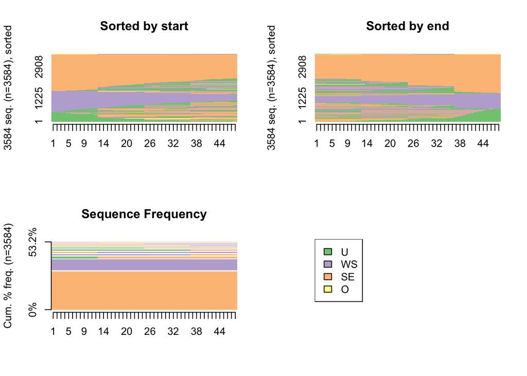

```r
par(mfrow = c(2, 2))
seqIplot(sipp.seq, sortv = "from.start", with.legend = FALSE, main = "Sorted by start")
seqIplot(sipp.seq, sortv = "from.end", with.legend = FALSE, main = "Sorted by end")
seqfplot(sipp.seq, with.legend = FALSE, border = NA, main = "Sequence Frequency")
seqlegend(sipp.seq, fontsize = 1)
```

Compute the optimal matching distances using substitution costs based on transition rates observed in the data and a 1 indel cost. The resulting distance matrix is stored in the dist.om1 object.

```r
dist.om1 <- seqdist(sipp.seq, method = "OM", indel = 1, sm = "TRATE")
```

```
##  [>] 3584 sequences with 4 distinct states
```

```
##  [>] Computing sm with seqcost using  TRATE
```

```
##  [>] creating substitution-cost matrix using transition rates ...
```

```
##  [>] computing transition probabilities for states U/WS/SE/O ...
```

```
##  [>] 1089 distinct  sequences
```

```
##  [>] min/max sequence lengths: 48/48
```

```
##  [>] computing distances using the OM metric
```

```
##  [>] elapsed time: 2.713 secs
```

Make a typology of the trajectories:

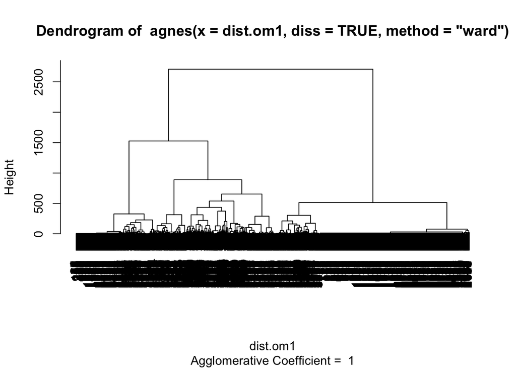

```r
library(cluster)
clusterward1 <- agnes(dist.om1, diss = TRUE, method = "ward")
plot(clusterward1, which.plot = 2)
```

Another way of viewing the tree above with the color coding for sequences and how they align with the clusters.

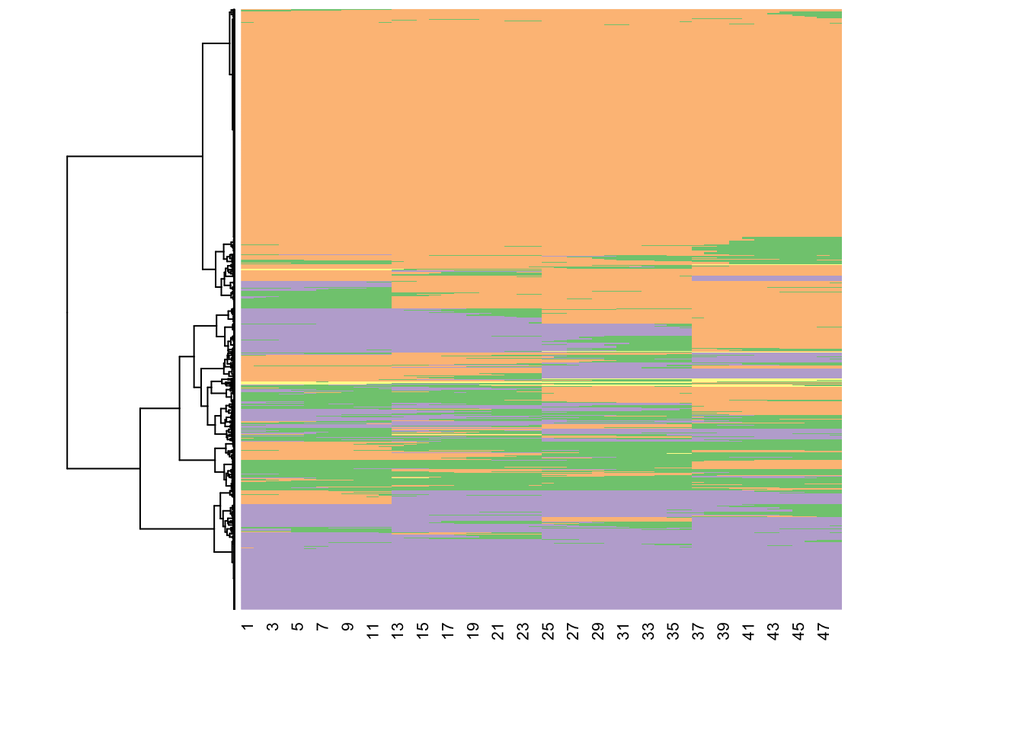

```r
seqhandbook::seq_heatmap(sipp.seq, clusterward1)
```

Getting a sense of where it might make sense to trim.

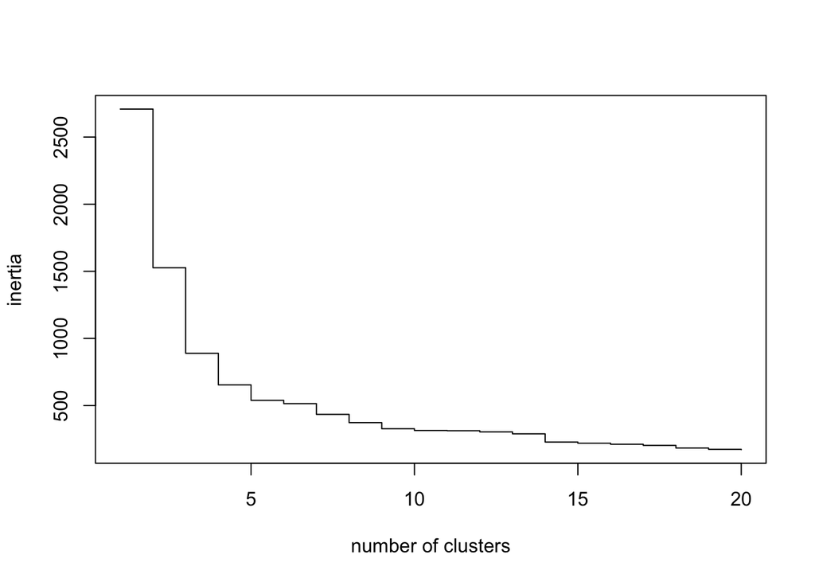

```r
plot(sort(clusterward1$height, decreasing=TRUE)[1:20], type="s", xlab="number of clusters", ylab="inertia")
```

```r
cl1.4 <- cutree(clusterward1, k = 6)
cl1.4fac <- factor(cl1.4, labels = paste("Type", 1:6))
```

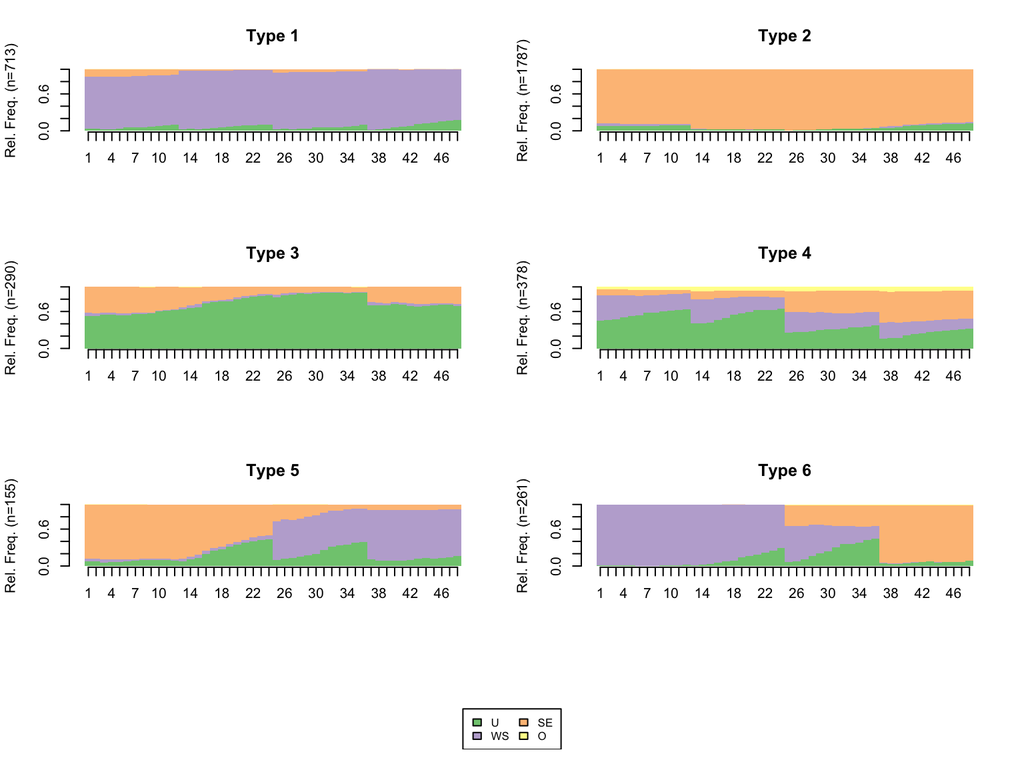

```r
seqdplot(sipp.seq, group=cl1.4fac, border=NA, cex.legend=0.8)
```

Plot all the sequences within each cluster.

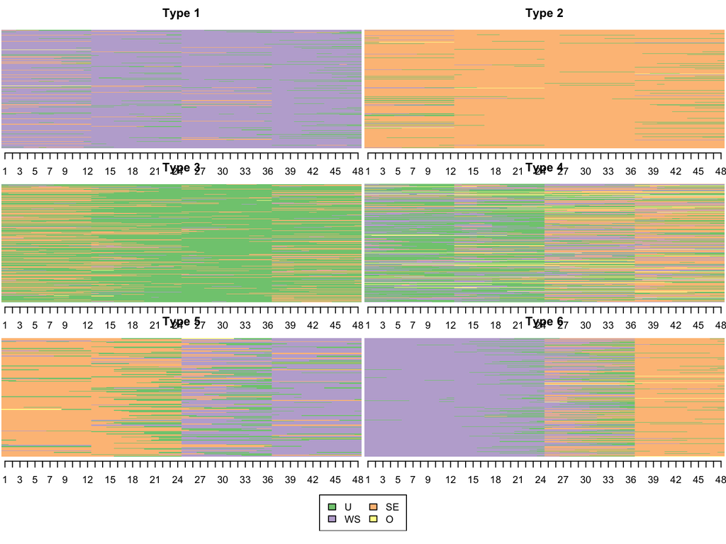

```r
opar <- par(mar=c(0, 0, 2, 0) + 0.1)
seqIplot(sipp.seq, group=cl1.4fac, border=NA,
          yaxis=FALSE)
```

```r
par(opar) ## resetting default margins
```

Again plotting all sequences, but sorting within each cluster by most representative cluster at the top of each figure and descending to those that are least similar at the bottom of each subfigure.

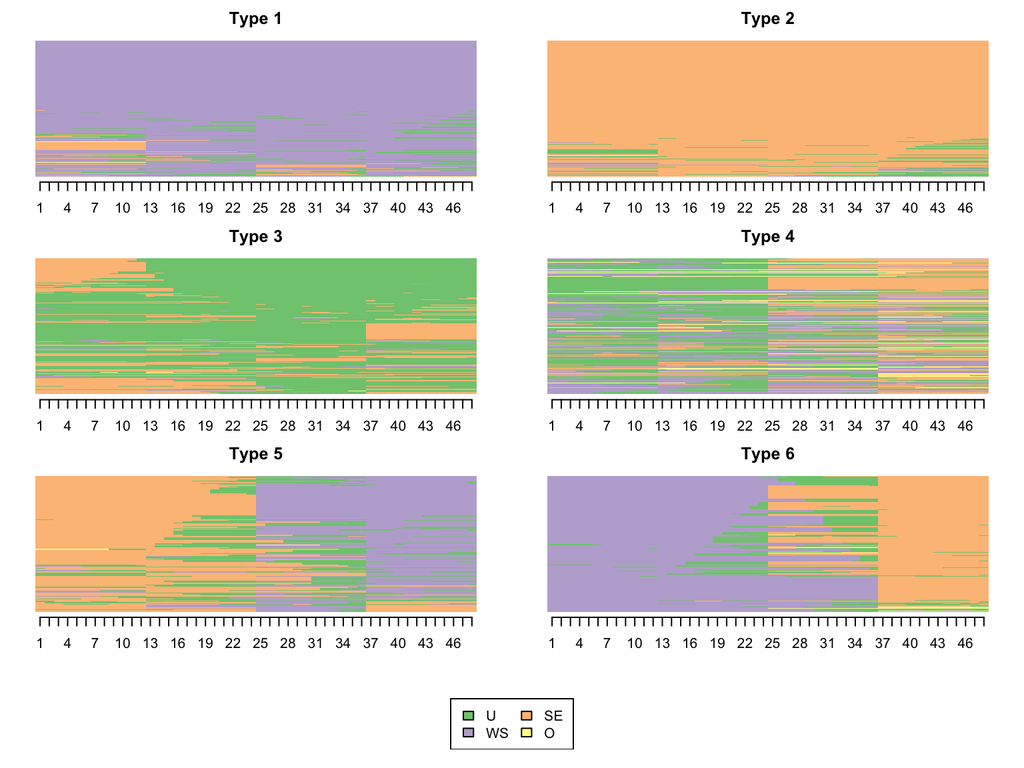

```r
opar <- par(mar=c(2, 2, 2, 2) + 0.1)
sil <- WeightedCluster::wcSilhouetteObs(dist.om1, cl1.4fac,measure = "ASWw")
seqIplot(sipp.seq, group = cl1.4fac, sortv = sil, yaxis = FALSE, ylab = "")
```

```r
par(opar)
```

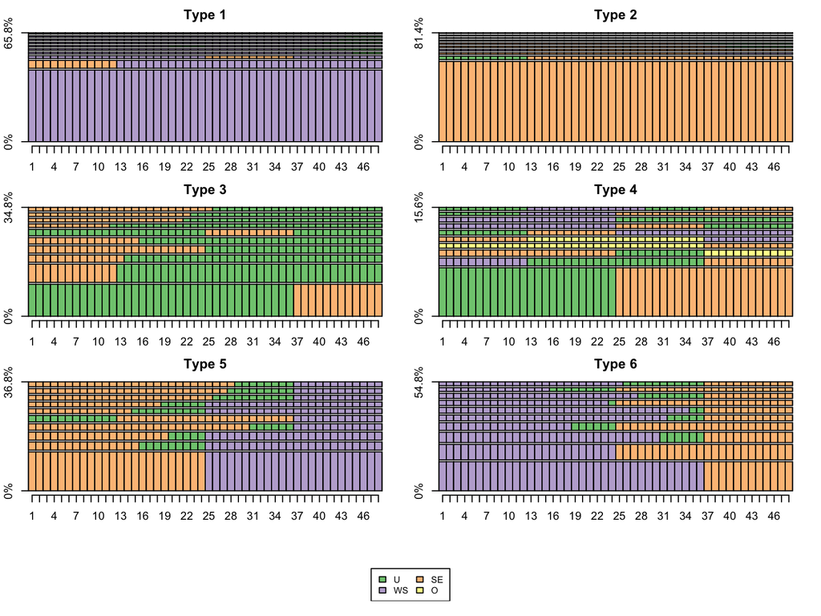

```r
opar <- par(mar=c(2, 2, 2, 2) + 0.1)
seqfplot(sipp.seq, group=cl1.4fac, ylab="", cex.legend=0.8)
```

```r
par(opar)
```

# To-dos

- still need to remove those without full years of data as they’ll throw off the sequences
- We can combine the ejb_jborse data with the rwkesr1-rwkesr5 to track employment at a weekly level.

  Coding for those variables is as follows:
  - 1. With job/business - working
  - 2. With job/business - not on layoff, absent without pay
  - 3. With job/business - on layoff, absent without pay
  - 4. No job/business - looking for work or on layoff
  - 5. No job/business - not looking for work and not on layoff

[figure not shown]

https://cran.r-project.org/web/packages/seqhandbook/vignettes/Tutorial.html

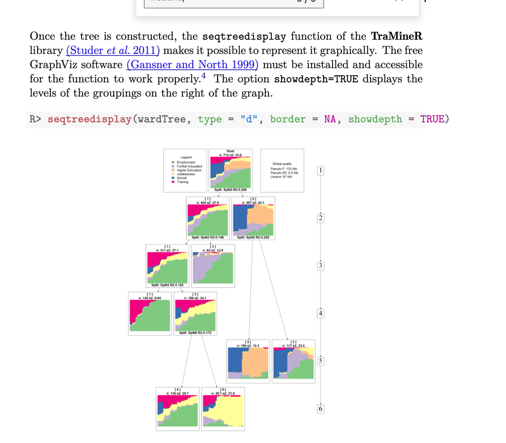

Resource to work on sequence commands https://traminer.unige.ch/preview-event.shtml

https://traminer.unige.ch/doc/seqMD.html

https://stackoverflow.com/questions/17020023/multiple-events-in-traminer

SIPP resources: https://www.census.gov/library/publications/2019/demo/p70br-163.html (use this as a check for the share of people holding multiple jobs to make sure my calculations are okay. )

https://www2.census.gov/programs-surveys/sipp/2023/2023_SIPP_PAA_Workshop_SEP23.pdf